# baseline_Unical

### Calculation of the Baseline Energy Consumption of the SmartHabits Pilot #1

```python
%matplotlib inline
```

```python
import numpy as np
import pandas as pd
import statsmodels.api as sm
import datetime
import patsy

from matplotlib import pyplot as plt
plt.rcParams['figure.dpi'] = 300
plt.rcParams['savefig.dpi'] = 300

import seaborn as sns
sns.set_style("ticks")
```

Read electricity data.

```python
data = pd.read_csv("Unical2013.csv", sep='\t', index_col=0, na_values="0", parse_dates=True,
                   date_parser=lambda s: datetime.datetime.strptime(s, "%d/%m/%Y").date())

data = data.apply(pd.Series.interpolate)
data.rename(columns={'24': '0'}, inplace=True)
```

Aggregate data into daily sums.

```python
data = pd.DataFrame(data.sum(axis=1), index=data.index, columns=['y'])
```

```python
'The mean daily electricity consumption is %d kWh' %data.mean()
```

```
'The mean daily electricity consumption is 103 kWh'
```

```python
'The total electricity consumption per annum is %d kWh' %data.sum()
```

```
'The total electricity consumption per annum is 34719 kWh'
```

The daily electricity consumption for 2013 (data for subsequent years is currently available only at monthly level) is depicted in the following plot. The effect of the summer holidays in August and the Christmas holidays, when the campus is closed from the 22nd December to the 7th January, is evident. Furthermore, it can be seen that daily electricity consumption is correlated with the mean daily ambient air temperature.

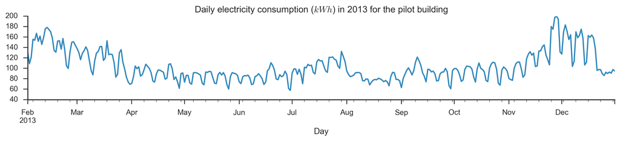

```python
fig, ax = plt.subplots(figsize=(14,2))

data.plot(ax=ax, kind='line', color="#348ABD", title='Daily electricity consumption ($kWh$) in '
                                                            '2013 for the pilot building')
ax.legend_.remove()
sns.despine(right=True);
```

Check for dependency of the electricity consumption on the ambient weather temperature.

First, load the corresponding temperature data. The data originate from the [Weather Underground](http://www.wunderground.com/history) service.

```python
weather_2013 = pd.read_csv("Calabria_2013.csv", sep=',', index_col=0,
                             date_parser=lambda s: datetime.datetime.strptime(s, "%Y-%m-%d").date())

mean_temperature = weather_2013['Mean TemperatureC']
```

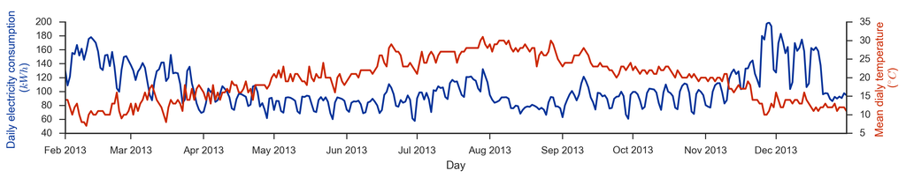

```python
fig, ax1 = plt.subplots(figsize=(14,2))

ax2 = ax1.twinx()
ax1.plot(data.index, data['y'], color="#003399")
ax2.plot(weather_2013.index, mean_temperature, color='#cc2900')

ax1.set_ylabel('Daily electricity consumption \n($kWh$)', color="#003399")
ax2.set_ylabel('Mean dialy temperature \n($^{\circ}C$)', color='#cc2900')
ax1.set_xlabel('Day')
sns.despine(right=False);
```

Is there a "day of week" effect?

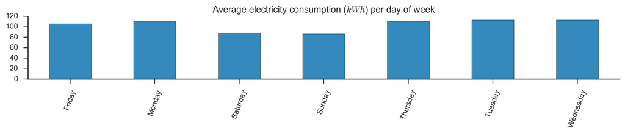

```python
day_of_week = {0: 'Monday', 1: 'Tuesday', 2: 'Wednesday', 3: 'Thursday', 4: 'Friday', 5: 'Saturday', 6: 'Sunday'}

data['weekday'] = data.index.map(lambda d: day_of_week[d.weekday()])

grouped = data.groupby('weekday').apply(np.mean)

fig, ax = plt.subplots(figsize=(14,1.5))

grouped.plot(ax=ax, kind='bar', color="#348ABD", title='Average electricity consumption ($kWh$) per day of week')
ax.legend_.remove()
plt.xlabel('')
plt.setp(ax.xaxis.get_majorticklabels(), rotation=70)
sns.despine(right=True);
```

Since the difference between weekdays and weekends is significantly larger than between different days, we can add a covariate that takes the value of one on a weekday and of zero otherwise. We can also capture the “holiday” effect by introducing a covariate that takes the value of one on a holiday and of zero otherwise.

```python
data['weekday'] = data.index.map(lambda d: 1 if d.weekday() in range(5) else 0)

summer = pd.date_range(start=datetime.date(2013, 8, 1), end=datetime.date(2013, 8, 31))
christmas = pd.date_range(start=datetime.date(2013, 12, 22), end=datetime.date(2014, 1, 7))
holidays = list(summer) + list(christmas)

data['holiday'] = data.index.map(lambda d: 1 if d.to_pydatetime() in holidays else 0)
```

The model that we used for the calculation of the baseline consumption has the following general form:

$$y_t = \alpha_t + \beta_t + f(T_t) + n_t$$

Where:

- $y_t$ denotes the demand at time $t$ (measured in daily intervals)
- $\alpha_t$ takes the value of one on a weekday and of zero otherwise (the “day of the week” effect)
- $\beta_t$ takes the value of one on a holiday and of zero otherwise (the “holiday” effect)
- $f(T_t)$ is a smooth function that models temperature effects; $T_t$ is the air temperature at time $t$
- $n_t$ denotes the model error at time $t$.

We will fit a penalized spline on the temperature-electricity consumption relationship.

Define a function that fits the spline given the target data `y`, the basis matrix `B`, the degrees of freedom `df` and the smoothing/regularization parameter $\lambda$.

```python
def spline_fit(y, B, df, lambda_=1.0):
    # build difference matrix
    P = np.diff(np.diag(np.ones(df)), n=1, axis=1)
    D = np.dot(P, P.T)
    # build the augmented matrices
    if(y.ndim ==1):
        y_ = np.vstack((np.expand_dims(y, axis=1), np.zeros((df, 1))))

    else:
        y_ = np.vstack((y, np.zeros((df, 1))))
    X_ = np.vstack((B, np.sqrt(lambda_) * D))

    return sm.OLS(y_, X_).fit()
```

Next, we define the [generalized cross-validation](http://www.stat.wisc.edu/~wahba/ftp1/oldie/golub.heath.wahba.pdf) score to choose the optimal value of $\lambda$. The GCV score is given by

$\operatorname{GCV}(\lambda) = \frac{n \sum_{i = 1}^n \left(y_i - \hat{y}_i\right)^2}{\left(n - \operatorname{tr} \mathbf{H}\right)^2}.$

Here, $\hat{y}_i$ is the $i$-th predicted value, and $\mathbf{H}$ is upper left $n \times n$ submatrix of the the influence matrix for the OLS model $\mathbf{\tilde{y}} = \mathbf{\tilde{X}} + \varepsilon$.

```python
def gcv_score(results, df):
    X = results.model.exog[:-df, :]
    n = X.shape[0]
    y = results.model.endog[:n]

    y_hat = results.predict(X)
    hat_matrix_trace = results.get_influence().hat_matrix_diag[:n].sum()

    return n * np.power(y - y_hat, 2).sum() / np.power(n - hat_matrix_trace, 2)
```

Finally, we define a function to combine spline fitting and cross-validation.

```python
def qspline(y, x, df, hasconst=False):

    if hasconst:
        basis_matrix = patsy.dmatrix('1 + cr(x, df)', {"x": x, "df": df})
        df += 1
    else:
        basis_matrix = patsy.dmatrix('cr(x, df) - 1', {"x": x, "df": df})

    lambdas = np.logspace(0, 50, 100, base=1.5) * 1e-8
    gcv_scores = np.array([gcv_score(spline_fit(y, basis_matrix, df, lambda_=lambda_), df) for lambda_ in lambdas])
    lambda_best = lambdas[gcv_scores.argmin()]
    results = spline_fit(y, basis_matrix, df, lambda_=lambda_best)
    return results, basis_matrix
```

Fit the model by backfitting.

```python
def backfit():
    rsquared = 0
    time_effects = 0
    spline_temperature = 0

    for _ in range(100):

        resid = data['y'] - time_effects
        results_temperature, basis_matrix = qspline(resid, mean_temperature, 4)
        spline_temperature = results_temperature.predict(patsy.build_design_matrices([basis_matrix.design_info],
                                                                                      {'x': mean_temperature})[0])

        if(abs(results_temperature.rsquared - rsquared) < 0.0001):
            print('Loop finished because R-squared stopped improving')
            break
        else:
            rsquared = results_temperature.rsquared
            resid = data['y'] - spline_temperature
            results_time = sm.OLS(resid, data[['weekday', 'holiday']]).fit()
            time_effects = results_time.predict(data[['weekday', 'holiday']])

    return spline_temperature, time_effects, results_temperature, results_time
```

```python
spline_temperature, time_effects, results_temperature, results_time = backfit()
```

```
Loop finished because R-squared stopped improving
```

Plot the spline.

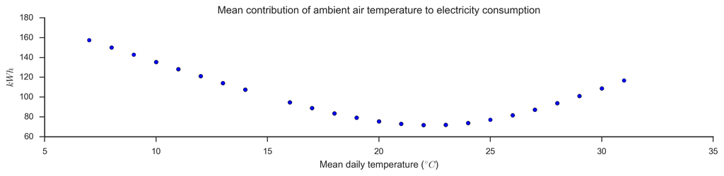

```python
fig, ax = plt.subplots(figsize=(14,2.5))

ax.scatter(mean_temperature, spline_temperature)

ax.set_xlabel('Mean daily temperature ($^{\circ}C$)')
ax.set_ylabel('$kWh$')
ax.set_title('Mean contribution of ambient air temperature to electricity consumption')
sns.despine(right=True);
```

The contribution of the day-of-week and holiday effects is:

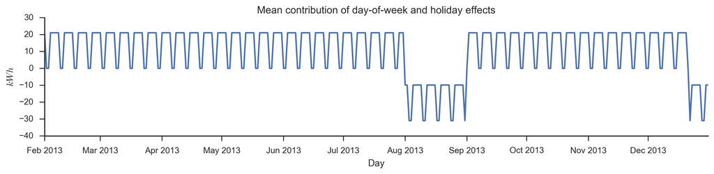

```python
fig, ax = plt.subplots(figsize=(14,2.5))

ax.plot(data.index, results_time.predict(data[['weekday', 'holiday']]))
ax.set_xlabel('Day')
ax.set_ylabel('$kWh$')
ax.set_title('Mean contribution of day-of-week and holiday effects')
sns.despine(right=True);
```

Plot the residuals.

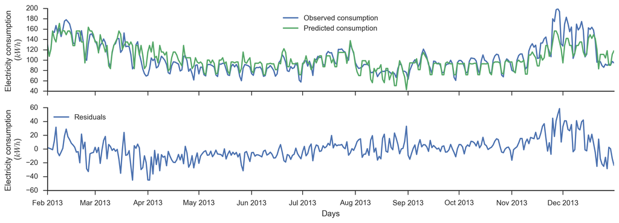

```python
fig, axes = plt.subplots(nrows=2, ncols=1, sharex=True, squeeze=True, figsize=(14, 4.5))

pred = spline_temperature + results_time.predict(data[['weekday', 'holiday']])

axes[0].plot(data.index, data['y'], label='Observed consumption')
axes[0].plot(data.index, pred, label='Predicted consumption')

axes[0].set_ylabel('Electricity consumption \n($kWh$)')
axes[0].legend(loc='best')

resid = data['y'] - pred
axes[1].plot(data.index, resid, label='Residuals')
axes[1].set_xlabel('Days')
axes[1].set_ylabel('Electricity consumption \n($kWh$)')
axes[1].legend(loc='best')

sns.despine(right=True);
```

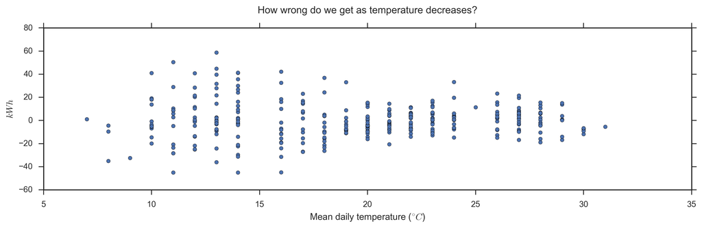

```python
fig, ax = plt.subplots(figsize=(14,3.5))
ax.set_title('How wrong do we get as temperature decreases?\n')

test_var = pd.DataFrame(resid, index=data.index)
test_var['temperature'] = mean_temperature
test_var.plot(kind='scatter', x='temperature', y='y', ax=ax)
ax.set_ylabel('$kWh$')
ax.set_xlabel('Mean daily temperature ($^{\circ}C$)');
```

Find all occurrences of temperature being lower than 18 $^{\circ}C$.

```python
relevant = data[test_var['temperature'] < 18]
```

What we could shave the upper 20% of the variance?

```python
target = 0.20 * (test_var['y'].max() - test_var['y'].min())
'%d kWh per day' %target
```

```
'20 kWh per day'
```

```python
'We could save ' '{:.2%}'.format(target * len(relevant) / data['y'].sum())
```

```
'We could save 7.35%'
```

```python
import warnings
warnings.simplefilter(action = "ignore", category = FutureWarning)
```

```python
from IPython.core.display import HTML


def css_styling():
    styles = open("styles/custom.css", "r").read()
    return HTML(styles)

css_styling()
```